# Exploratory Data Visualizations - Federal Budget Data

Ian Lyons

1/27/2019

```
## here() starts at /Users/ianlyons/Documents/2019 Winter/Data Visualization/fed_budget
```

## Read in Tax Expenditure and Federal Outlays Data

- Source for tax expenditures on the Treasury Department Website: https://home.treasury.gov/policy-issues/tax-policy/tax-expenditures
- Source for federal outlays on the Office of Management and Budget website: https://www.whitehouse.gov/omb/supplemental-materials/

```r
base_df <- read_csv(file = "raw_data/tax_expenditures_18to28_renamed.csv")
rev <- read_csv(file = "raw_data/receipts-fy2019.csv")
budg_2019 <- read_csv(file = "raw_data/outlays-fy2019.csv")
```

## Reshape Tax Expenditure Dataframe For Plot 1

- Create a long-form version of the tax expenditures dataset to use in a time-series plot. That is, create one row for each category, detail, and fiscal year.
- Drop the cumulative ‘FY2019_to_2028’ column since I won’t be using it.

```r
tax_long <- gather(base_df, fiscal_year, expenditure, "2018":"2028", factor_key = TRUE)
tax_long$FY2019_to_2028 <- NULL
```

## Plot 1: Projected Tax Expenditures By Policy Category

- Create a time-series dataset so that tax expenditures can be compared over the fiscal years included.
- Convert the expenditure column to be in billions of dollars by dividing by 1000 (the tax expenditures dataset is in millions of dollars by default).

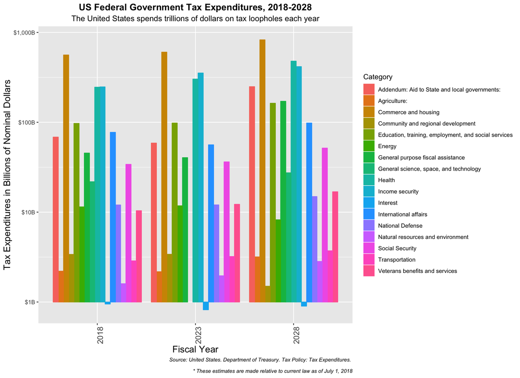

```r
time_series <- tax_long %>% select(fiscal_year, Category, expenditure) %>% filter(fiscal_year %in%
    c(2018, 2023, 2028)) %>% group_by(fiscal_year, Category) %>% tally(expenditure)

time_series <- mutate(.data = time_series, amount_billions = n/1000)
time_series$n <- NULL

bar_to_plot <- ggplot(data = time_series, aes(x = fiscal_year, y = amount_billions,
    color = Category, fill = Category)) + geom_col(position = "dodge")

plot1 <- bar_to_plot + scale_y_log10(name = "Tax Expenditures in Billions of Nominal Dollars",
    labels = scales::dollar_format(accuracy = 1, suffix = "B")) + scale_x_discrete(name = "Fiscal Year") +

labs(title = "US Federal Government Tax Expenditures, 2018-2028", subtitle = "The United States spends trillions of dollars on tax loopholes each year",
    caption = "Source: United States. Department of Treasury. Tax Policy: Tax Expenditures. \n
         * These estimates are made relative to current law as of July 1, 2018",
    x = "Fiscal Year") +
theme(plot.title = element_text(color = "black", size = 14, face = "bold", hjust = 0.5),
    plot.subtitle = element_text(color = "black", size = 12, hjust = 0.5), axis.title.x = element_text(color = "black",
        size = 14), axis.text.x = element_text(angle = 90, hjust = 1, size = 12),
    axis.title.y = element_text(color = "black", size = 14), plot.caption = element_text(color = "black",
        size = 8, face = "italic"))
plot1
```

# Prep For Plots 2 & 3: Group by agency name and sum expenditures within the same agency and year.

- Create a long-form version of the outlays dataset to use in a time-series plot. That is, create one row for each line item (agency name, bureau name, account name, etc.) and fiscal year.

```r
budget_longform <- gather(budg_2019, fiscal_year, expenditure, "1962":"2018",
    factor_key = TRUE)

## Keep only descriptive column names rather than codes.
keep_cols <- c("Agency Name", "Bureau Name", "Account Name", "Treasury Agency Code",
    "Subfunction Title", "BEA Category", "Grant/non-grant split", "On- or Off- Budget",
    "fiscal_year", "expenditure")

budget_longform <- budget_longform[keep_cols]
```

- Take the reshaped longform budget data and group by fiscal year and agency name.

```r
outlays <- budget_longform %>% select(fiscal_year, `Agency Name`, expenditure) %>%
    group_by(fiscal_year, `Agency Name`) %>% tally(expenditure)

## Give the expenditures column a descriptive name
outlays <- mutate(.data = outlays, dollars_thousands = n)
outlays$n <- NULL

## Rename `Agency Name` in snake case.
colnames(outlays)[2] <- "agency_name"
```

## Plot 2: FacetWrap Grid Showing the Annual Outlays 1995-2018 of Some of the Largest Agencies & Departments

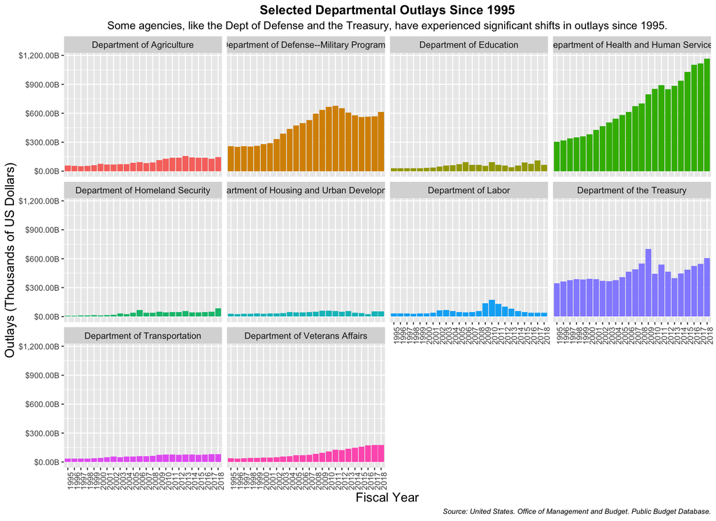

```r
outlays %>% filter(fiscal_year %in% c(1995:2018)) %>% filter(agency_name %in%
    c("Department of Agriculture", "Department of Defense--Military Programs",
        "Department of Education", "Department of Health and Human Services",
        "Department of Homeland Security", "Department of Housing and Urban Development",
        "Department of Labor", "Department of the Treasury", "Department of Transportation",
        "Department of Veterans Affairs")) %>%
ggplot(aes(x = fiscal_year, y = dollars_thousands, fill = agency_name)) + geom_histogram(stat = "sum") +
    facet_wrap(~agency_name) + scale_y_continuous(name = "Outlays (Thousands of US Dollars)",
    labels = scales::dollar_format(scale = 1e-06, accuracy = 0.01, suffix = "B")) +

labs(title = "Selected Departmental Outlays Since 1995", subtitle = "Some agencies, like the Dept of Defense and the Treasury, have experienced significant shifts in outlays since 1995.",
    caption = "Source: United States. Office of Management and Budget. Public Budget Database.",
    x = "Fiscal Year", y = "Outlays In Thousands of US Dollars ") +
theme(axis.text.x = element_text(angle = 90), strip.text = element_text(face = "plain",
    size = rel(0.9)), plot.title = element_text(color = "black", size = 14,
    face = "bold", hjust = 0.5), plot.subtitle = element_text(color = "black",
    size = 12, hjust = 0.5), axis.title.x = element_text(color = "black", size = 14),
    axis.title.y = element_text(color = "black", size = 14), plot.caption = element_text(color = "black",
        size = 8, face = "italic"), legend.position = "none")
```

# Plot 3: Federal Government Outlays by Agency By Year

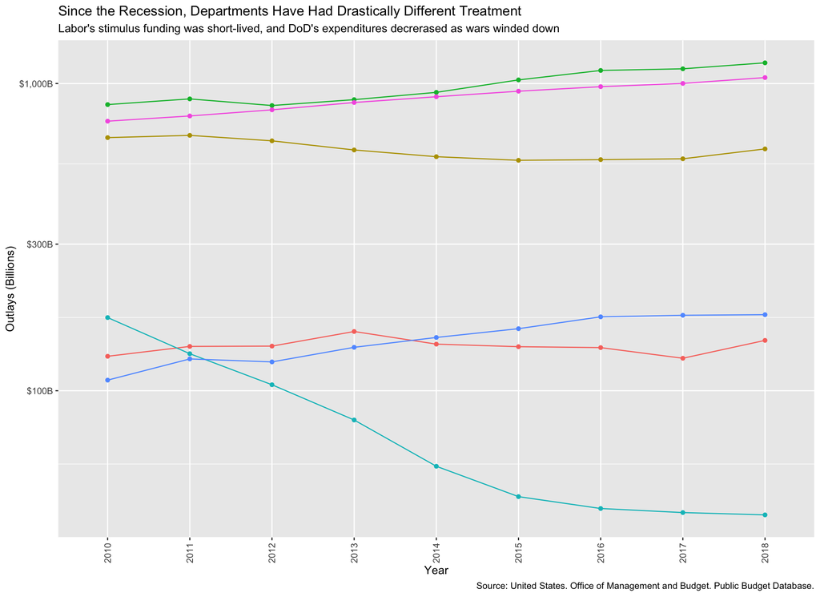

```r
outlays %>%
  filter(agency_name %in% c("Social Security Administration","Department of Health and Human Services",
                            "Department of Defense--Military Programs", "Department of Agriculture",
                            "Department of Veterans Affairs", "Department of Labor")) %>%

    filter(fiscal_year %in% c(2010, 2011, 2012, 2013, 2014, 2015, 2016, 2017, 2018)) %>%

  group_by(agency_name, fiscal_year) %>%
  summarize(dollars_thousands = sum(dollars_thousands)) %>%

      ggplot(aes(x = fiscal_year, y = (dollars_thousands), color = agency_name, group=agency_name)) +
      geom_point() + geom_line() + ggpubr::rotate_x_text() + theme(legend.position="none") +
      scale_y_log10(name = "Outlays (Billions)", labels = scales::dollar_format(scale=.000001, accuracy = 1, suffix = 'B')) +

        labs(title = "Since the Recession, Departments Have Had Drastically Different Treatment",
          subtitle = "Labor's stimulus funding was short-lived, and DoD's expenditures decrerased as wars winded down",
          caption = "Source: United States. Office of Management and Budget. Public Budget Database.",
          x = "Year",
          y = "Outlays (Thousands of US Dollars)" +

          theme(plot.title = element_text(color="black", size=14, face="bold", hjust = 0.5),
              plot.subtitle = element_text(color="black", size=12, hjust =0.5),
              axis.title.x = element_text(color="black", size=14, angle = 90),
              axis.title.y = element_text(color="black", size=14),
              plot.caption = element_text(color="black", size=8, face="italic")
              )
        )
```

## Plot 4: Discretionary vs Mandatory at the Agency Level

I don’t like this plot and I’m going to get rid of it. ¯_(ツ)_/¯

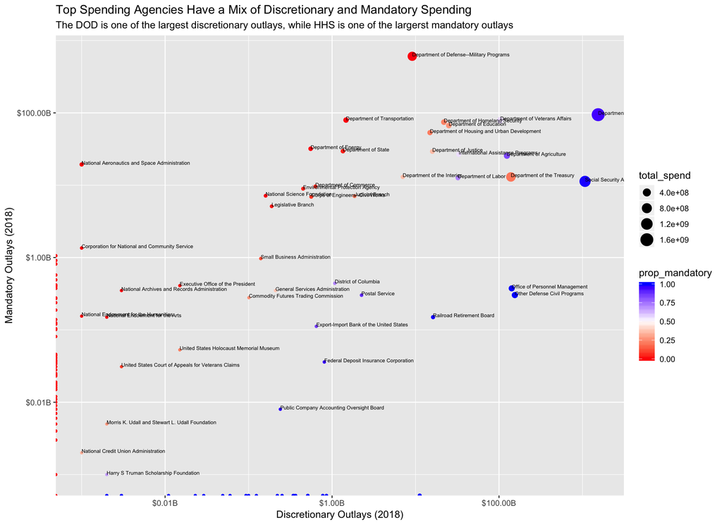

## Plot 5: Share of Spending Over Time

The share of federal spending classified as mandatory has grown as a percentage of total spending since the 1960s.

Mandatory spending is spending controlled by laws other than annual appropriations acts. This spending has been mandated by Congress in the past and does does have to be reappropriated each year. Most mandatory programs are fall under health care (e.g. Medicare, Medicaid), social security, and other income support programs. Spending on mandatory programs is determined by the number of eligible recipients.

Discretionary spending must be appropriated each year by the House and Senate. The largest portion of discretionary spending is funding for the Department of Defense and other defense-related programs. Non-defense discretionary spending, just under half of total discretionary spending in 2018, accounts for all federal spending on diplomacy, education, transportation, research, law enforcement, and paying for the operations of the federal government.

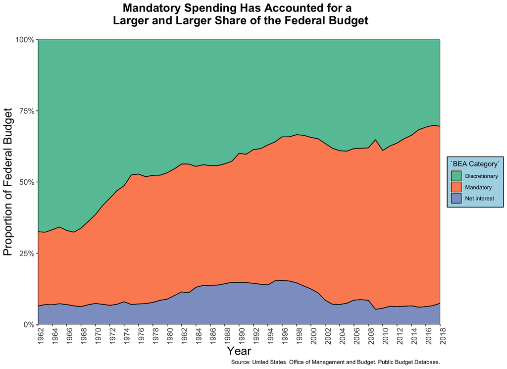